# Operational Hydrological Forecasts with GR4/6J-CemaNeige-Glacier Module in Glaciated Terrains using Data Assimilation

Adrian Kreiner, Beartrice Marti, Sandro Hunziker, Tobias siegfried

# Introduction

## Scope

The GR4J/GR6J-CemaNeige model developed by Perrin, Michel, and Andréassian (2003), Pushpalatha et al. (2011) and Valéry, Andréassian, and Perrin (2014) is highly effective for simulating discharge in lowland and mountainous areas. However, it lacks a glacier component, making it unsuitable for modeling discharge in highly glaciated areas Pokhrel et al. (2014).

We propose a simple, robust, and effective glacier module that integrates perfectly into the GR4J/GR6J-CemaNeige model setup.

In this vignette, we show the following:

## Data preparation

For this vignette, we need a digital elevation model (DEM). We are using the one from the **Shuttle Radar Topography Mission (SRTM)**, which can be downloaded from [Earth Explorer](https://hydrosolutions.github.io/caham_book/appendix_c_quick_guides.html#section-earth-explorer-download-srtm). We also need data for the glacier outlines, which can be downloaded from the Randolph [Glacier Inventory (RGI) v7.0](https://www.glims.org/RGI/). Additionally, we need the catchment area in m², basin latitude in radians, the basin code, and the basin river name. We also need the basin outlines, which can be obtained under [HydroBASINS](https://www.hydrosheds.org/products/hydrobasins).

# 1. General basin specific setup

In this section, we are calculating basin-specific characteristics needed for the hydrological model. From the DEM, we are calculating the hypsometric curve. We are extracting the latitude and basin area from the basin outlines. Using the DEM we also delineate the hydrological response units (HRUs) for the CemaNeige and glacier modules.

## 1.1 Load data and calculate basin specific characteristics

```r
# data directories
data_dir <- "/Volumes/Transcend/hydrosolutions Dropbox/Adrian Kreiner/SAPPHIRE_Central_Asia_Technical_Work/data/vignette"
dir_CHELSA <- "/Volumes/Transcend/hydrosolutions Dropbox/Adrian Kreiner/SAPPHIRE_Central_Asia_Technical_Work/data/forcing/15194_AlaArcha/CHELSA_V21"
dir_linreg <- "/Volumes/Transcend/hydrosolutions Dropbox/Adrian Kreiner/SAPPHIRE_Central_Asia_Technical_Work/code/pentadal_forecasting_system/hindcast_results/20240527"

# Projection UTM 42N
utm42n <- "EPSG:32642"
crs_project <- 4326


# load the basin
basin_latlon <- st_read(paste0(data_dir,"/15194_AlaArcha_latlon.shp"), quiet = TRUE)
basin_utm <- st_transform(basin_latlon, utm42n)

# load DEM:
dem_latlon <- terra::rast(paste0(data_dir,"/15194_DEM_latlon.tif")) # dem is in utm 42
dem_utm <- terra::project(dem_latlon, utm42n)

# Hypsometric curve:
getHypsometricCurve <- function(dem) {
  elevation_values <- terra::values(dem)
  elevation_values <- elevation_values[!is.na(elevation_values)]
  percentiles <- c(0, seq(1, 99, by = 1), 100)
  hypso_data <- stats::quantile(elevation_values, probs = percentiles / 100)
  return(hypso_data)
}
HypsoData <- getHypsometricCurve(dem_utm)



# Basin Information
Basin_code <- 15194
river_name <- "AlaArcha"
BasinArea_m2 <- as.numeric(st_area(basin_utm))

basin_coords <- st_centroid(basin_latlon) |> st_coordinates()
basin_lat <- basin_coords[, "X"]

Basin_Info <- list(
  BasinCode = Basin_code,
  BasinName = river_name,
  BasinArea_m2 = BasinArea_m2,
  BasinLat_rad = basin_lat,
  HypsoData = as.numeric(HypsoData))
```

## 1.2 HRU delineation

Five elevation bands with equal areas are delineated using the hypsometric curve.

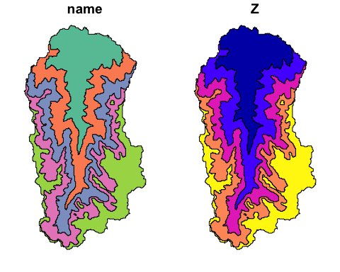

```r
Zlayer <- 5
min_elev <- HypsoData[1]
max_elev <- HypsoData[length(Basin_Info$HypsoData)]



# HYPSOMETRIC CURVE
# mask dem
dem_masked <- dem_utm |> crop(basin_utm) |> mask(basin_utm)
dem_masked_vec <- dem_masked[] |> na.omit()

# NEW
h_range <- c(HypsoData[1], HypsoData[21], HypsoData[41], HypsoData[61], HypsoData[81], HypsoData[101])
# classify
dem_utm_class <- classify(dem_utm, h_range)
# polygonize
dem_utm_class_poly <- as.polygons(dem_utm_class)
dem_utm_class_poly_sf <- st_as_sf(dem_utm_class_poly)
dem_utm_class_poly_sf <- dem_utm_class_poly_sf |>
    mutate(layer = seq(nrow(dem_utm_class_poly_sf)))
# clip and rename
hru_shp_clipped_utm <-
    st_intersection(dem_utm_class_poly_sf, basin_utm) |>
    dplyr::select(layer, geometry)
hru <- hru_shp_clipped_utm

hru$name <- river_name
zonalStat_Z <- exactextractr::exact_extract(dem_utm,hru,'mean', max_cells_in_memory = 3e+08, progress = FALSE)
hru$Z <- zonalStat_Z

# unique names in hru
subbasin_names <- unique(hru$name)
# loop through subbasin_names and add unique numbers to corresponding names
for (idx in length(subbasin_names)) {
  subbasin_sel <- hru |> dplyr::filter(name == subbasin_names[idx]) |> dplyr::arrange(Z)
  subbasin_sel$hru_num <- (1:base::nrow(subbasin_sel))
  subbasin_sel$name <- paste0(subbasin_sel$name,'_',subbasin_sel$hru_num)

  if (idx == 1) {
    res_subbasins <- subbasin_sel
  } else {
    res_subbasins <- res_subbasins %>% dplyr::add_row(subbasin_sel)
  }
}

hru_named_utm <- res_subbasins %>% dplyr::select(-layer,-hru_num)
hru_named_latlon <- hru_named_utm |> st_transform(crs = crs_project) |> st_make_valid()
hru_named_utm %>% plot()
```

## 1.3 Glacier area

```r
# load glacier
glacier_merged <- st_read(paste0(data_dir,"/15194_Glacier.shp"), quiet = TRUE) # it is latlon, RGI V7
glacier_utm <- st_transform(glacier_merged, utm42n)


hru_named_utm <- hru_named_utm %>%
  mutate(Area_km2 = set_units(st_area(.), km^2))

# Calculate glacier area in each elevation band
glaciated_areas <- st_intersection(hru_named_utm, glacier_utm) %>%
  mutate(glaciated_area_km2 = set_units(st_area(.), km^2))

# Aggregate glaciated areas by elevation band
aggregated_data <- glaciated_areas %>%
  group_by(name) %>%
  summarise(glaciated_area_km2 = sum(glaciated_area_km2, na.rm = TRUE)) %>%
  rename(elev_band = name)

glaciated_area_df <- data.frame(elev_band = hru_named_utm$name)
# join with aggregated_data
glaciated_area_df <- merge(glaciated_area_df, aggregated_data, by = "elev_band", all.x = TRUE)
# replace Na with 0
glaciated_area_df[is.na(glaciated_area_df)] <- 0
glaciated_area_df$glaciated_area_km2 <- set_units(glaciated_area_df$glaciated_area_km2, km^2)

hru_named_utm_df <- as.data.frame(st_drop_geometry(hru_named_utm)) %>%
  select(elev_band = name, Area_km2)

glaciated_area_df <- hru_named_utm_df %>%
  left_join(aggregated_data, by = "elev_band") %>%
  mutate(glaciated_area_km2 = replace_na(glaciated_area_km2, set_units(0, km^2)))


# Create the final basin data frame
basin_df <- data.frame(elev_band = hru_named_utm$name,
                   soil_area = hru_named_utm$Area_km2 - glaciated_area_df$glaciated_area_km2,
                   ice_area = glaciated_area_df$glaciated_area_km2,
                   total_area = hru_named_utm$Area_km2)

basin_df$rel_soil <- basin_df$soil_area/sum(basin_df$total_area)
basin_df$rel_ice <- basin_df$ice_area/sum(basin_df$total_area)
basin_df$h <- basin_df$Z

# Convert relative ice and soil areas to numeric
rel_ice <- as.numeric(basin_df$rel_ice)
rel_soil <- as.numeric(basin_df$rel_soil)

# Vizulization
tmap_mode("view")
```

```
## tmap mode set to interactive viewing
```

```r
tm_shape(hru_named_utm) +
  tm_polygons(col = "blue", border.col = "darkblue", alpha = 0.5) +
  tm_shape(glaciated_areas) +
  tm_polygons(col = "name", border.col = "darkred", alpha = 1)
```

[interactive chart not shown]

# 2. Basin specific lapse rates

## 2.1 Downlaod gridded CHELSA V21 data

```r
start_year <- 1990
end_year <- 2020


startdate <- ymd(paste(start_year,"-1-1"))
enddate <- startdate + years(1) - days(1)
# number of years to fetch
n_years <- end_year - start_year + 1

extent <- sf::st_bbox(basin_latlon)
extent <- c(extent$xmin, extent$xmax, extent$ymin, extent$ymax) |> unname()

for (idx in seq(n_years)) {
    year_name <- year(startdate) |> as.character()
    # temperature tas (note: this is in Kelvin, we need to convert to Celsius.)
    tas <- Rchelsa::getChelsa('tas',extent = extent, startdate = startdate, enddate = enddate)
    tas <- tas - 273.15
    # precipitation pr
    pr <- Rchelsa::getChelsa('pr',extent = extent, startdate = startdate, enddate = enddate)
    # if not already existing, save tas and pr data on disk
    if (!file.exists(file.path(CHELSA_dir,paste0("tas_",year_name,".nc")))) {
        writeCDF(tas, file.path(CHELSA_dir,paste0("tas_",year_name,".nc")),overwrite=TRUE)}
    if (!file.exists(file.path(CHELSA_dir,paste0("pr_",year_name,".nc")))) {
        writeCDF(pr, file.path(CHELSA_dir,paste0("pr_",year_name,".nc")),overwrite = TRUE)}
    # shift dates
    startdate <- enddate + days(1)
    enddate <- startdate + years(1) - days(1)
}
```

## 2.2 Calculate temperature-specific lapse rate

For each day and cell, we sort the air temperature by elevation. To do this, we need to resample the DEM to match the resolution of the CHELSA V21 raster and extract the temperature data downloaded from the previous step and sort by elevation for each cell from the resampled DEM. A linear function is fitted, with the slope representing the temperature lapse rate. This process is repeated daily over a 30-year period. The daily lapse rates are then averaged for each day of the year.

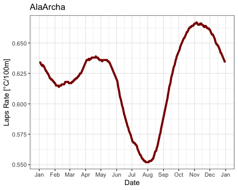

```r
# Calculates daily lapse rates from a raster stack of temperature data, returning a vector of lapse rates for each day
# Input:
# file_path_raster: Path to the raster file with temperature data (CHELSA V21) stores as year for each da
# elevation_values: Elevation values of the basin for each cell (NaN is outside the basin)
# Output:
# slopes: Numeric vector with lapse rates (°C/m) for each day for a specific year (raster stack)
get_T_lapsrate_daily <- function(file_path_raster, elevation_values) {
  raster_all <- terra::rast(file_path_raster)
  n_layer <- nlyr(raster_all)
  slopes <- numeric(n_layer)
  data_list <- list()
  # Loop through each layer (days) and extract values
  for (i in 1:n_layer) { #n_layer
    raster_one <- raster_all[[i]]
    raster_value <- values(raster_one)

    temp_data <- data.frame(elevation = elevation_values[,1], value = raster_value[,1])
    # remove all rows with NA values --> outside of the basin
    temp_data <- temp_data[!is.na(temp_data$elevation),]
    # calculate the slope of the specific day (= lapse rate of this day)
    model <- lm(value ~ elevation, data = temp_data)
    slopes[i] <- coef(model)["elevation"]*1000
  }
  return(slopes)
}

# load the downloaded CHELSA files
nc_files <- list.files(dir_CHELSA, pattern = ".nc$", full.names = TRUE)
temp_files <- nc_files[str_detect(nc_files, "tas")]

# Resample DEM to the same resolution as CHELSA V21 data.
temperature_layer <- terra::rast(temp_files[1])[[1]]
resampled_dem <- resample(dem_latlon, temperature_layer, method = "bilinear")
elevation_values <- terra::values(resampled_dem)

# calculate the temperature lapse rates
lapsrate_t_years <- lapply(temp_files, function(x) get_T_lapsrate_daily(x, elevation_values))
lapsrate_matrix <- do.call(rbind, lapsrate_t_years)

daily_means <- round(colMeans(lapsrate_matrix)*-0.1, 3) # convert to 100m/C
dates <- seq(as.Date("2020-01-01"), as.Date("2020-12-31"), by="day")
days <- format(dates, "%d")
months <- format(dates, "%m")
daily_stats <- data.frame(
  Day = days,
  Month = months,
  Mean = daily_means
)

# The temperature lapse rate is smoothed with a 30-day rolling mean
extend_and_smooth_data <- function(data, year = 2020, window_size = 30) {
  data <- data %>% mutate(Date = as.Date(paste(year, Month, Day, sep = "-")))

  # For Rolling mean
  December <- filter(data, Month == "12")
  December$Date <- December$Date %m-% years(1)
  January <- filter(data, Month == "01")
  January$Date <- January$Date %m+% years(1)
  data_extended <- rbind(December, data, January)

  # Smooth the data
  data_extended$Mean_smooth <- zoo::rollmean(data_extended$Mean, window_size, fill = NA, align = 'center')
  # Filter out the extended parts
  data_final <- filter(data_extended, Date >= as.Date(paste(year, "01-01", sep = "-")),
                       Date <= as.Date(paste(year, "12-31", sep = "-")))

  # Select and rename the necessary columns
  data_final <- select(data_final, Day, Month, Mean_smooth) %>%
    rename(Mean = Mean_smooth) %>%
    mutate(Mean = round(Mean, 3)) %>%  # round to 3 digits
    mutate(Min = 0, Max = 0)  # Reset Min and Max as placeholders ( do not need for GR4J, GR6J model in the current implementation)
  return(data_final)
}

daily_stats_smoothed <- extend_and_smooth_data(daily_stats)
# write.table(daily_stats_smoothing_finished, file = "../LapsrateT_daily_1990_2019_InflowToktogul_smoothing30.txt", row.names = FALSE, quote = FALSE, sep = ",", col.names = TRUE)

# Visualization
daily_stats_smoothing_plot <-daily_stats_smoothed %>%
  mutate(Date = as.Date(paste("2020", Month, Day, sep = "-"), format = "%Y-%m-%d"))

ggplot() +
  geom_line(data = daily_stats_smoothing_plot, aes(x = Date, y = Mean, colour = "Laps rate T"), color = "darkred", linewidth = 1.5) +
  labs(title = river_name,
       x = "Date",
       y = "Laps Rate [°C/100m]")+scale_x_date(date_breaks = "1 month", date_labels = "%b")+
  theme_bw()
```

Now the temperature lapse rate data saved as a CSV file has to be included in the UtilsCemaNeige.R file with a name, for example: .GradT_Interpol_15194 (open for improvement). In the function DataAltiExtrapolation_Valery.R, add the temperature lapse rate. Then in the function CreateInputsModel.R, please provide the Code_lapseRate.

## 2.3 Calculate precipitation-specific lapse rate

To account for the effect of altitude in estimating precipitation, we chose a different method than the one used for air temperatures: a multiplicative correction rather than the traditional additive correction. Precipitation data is either positive or zero, and using an additive method would not preserve dry events. The correction applied should also depend on the amount of precipitation that has fallen:

$$P_i = P_0 \exp(\beta_{\text{Altitude}}
(Z_i - Z_0))$$

Where $P_i$ [mm/d] is the precipitation at elevation $Z_i$ [m a.s.l.], $P_0$ [mm/d] is the mean precipitation over the basin mean elevation at $Z_0$ [masl], and $\beta_{\text{Altitude}}$ [m] is the altitudinal correction factor for precipitation.

The precipitation lapse rate is calculated by first determining the 30-year mean precipitation for each cell. With the resampled DEM, each precipitation cell is given an elevation. Precipitation values above 4000m are not considered, and constant precipitation is assumed at that altitude. The equation above was then used to fit the altitudinal correction factor for precipitation to the elevation-dependent precipitation data.

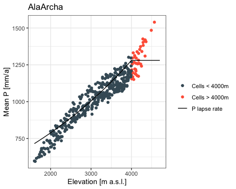

```r
# Calculates total lapse rates from a raster stack of precipitation data, returning a vector of lapse rates for each day
# Input:
# file_path_raster: Path to the raster file with temperature data (CHELSA V21) stores as year for each day
# elevation_values: Elevation values of the basin for each cell (NaN is outside the basin)
# Output: elevation dependend precipitation as mean in mm/a for the basin over the input period (specified in the file_path with multiple yearly files)
get_P_lapsrate <- function(file_path, elevation_values) {

  raster_allall <- do.call(c, lapply(file_path, terra::rast))
  Tot_period_mean <- terra::app(raster_allall, fun=mean, by=1:nlyr(raster_allall))* 365 # 30 year mean

  raster_value <- values(Tot_period_mean)
  temp_data <- data.frame(elevation = elevation_values[,1], value = raster_value[,1])
  temp_data <- temp_data[!is.na(temp_data$elevation),]

  # Linear regression
  model <- lm(value ~ elevation, data = temp_data)
  slopes <- coef(model)["elevation"]*1000 # per thousand meter
  return(temp_data)
}

# Get the precipitation mean over the total period and sort it by elevation.
pr_files <- nc_files[str_detect(nc_files, "pr")]
lapsrate_p_data <- get_P_lapsrate(pr_files, elevation_values)
lapsrate_p_data <- lapsrate_p_data[order(lapsrate_p_data$elevation),]

# Do not consider values above 4000m
P_elev_data_4000 <- lapsrate_p_data %>%
  filter(elevation <= 4000)

P_elev_data_bigger4000 <- lapsrate_p_data %>%
  filter(elevation > 4000)

Z0 <- median(Basin_Info$HypsoData)
# getting P0 : Linear interpolation from closest values
closest_points <- P_elev_data_4000 %>%
  arrange(abs(elevation - Z0)) %>%
  slice(1:2)
P0 <- approx(closest_points$elevation, closest_points$value, xout = Z0)$y

model <- nls(value ~ P0 * exp(k * (elevation - Z0)), data = P_elev_data_4000, start = list(k = 0.00046))
k_value <- coef(model)['k']


# Visualization
elevation_seq <- seq(min(lapsrate_p_data$elevation),4000, length.out = 100)
predicted_values <- P0 * exp(k_value * (elevation_seq - Z0))
plot_data <- data.frame(Elevation = elevation_seq, Predicted_Value = predicted_values)
value_at_max_elevation <- plot_data$Predicted_Value[nrow(plot_data)]

new_row <- data.frame(Elevation = 4700, Predicted_Value = value_at_max_elevation)
plot_data <- rbind(plot_data, new_row)


ggplot() +
  geom_point(data = P_elev_data_bigger4000, aes(x = elevation, y = value, color = "Cells > 4000m"))+
  geom_point(data = P_elev_data_4000, aes(x = elevation, y = value, color = "Cells < 4000m"))+
  geom_line(data = plot_data, aes(x = Elevation, y = Predicted_Value, color = "P lapse rate"))+
  labs(title =river_name, x = "Elevation [m a.s.l.]", y = "Mean P [mm/a]") +
  theme_bw()+
  scale_color_manual(
    name = "",  # Legend title (blank if not needed)
    values = c("Cells > 4000m" = "#FF6347", "Cells < 4000m" = "#435A66", "P lapse rate" = "black")
  )
```

The altitudinal correction factor can now be included in DataAltiExtrapolation_Valery.R and called with CreateInputsModel.R using the Code_lapseRate (= Basincode).

# 3. Data preparation

## 3.1 SWE data extraction

## 3.2 PET data extraction

## 3.2 Forcing data

```r
base::load(paste0(data_dir,"/basinObsTS_SWE.RData"))
summary(basinObsTS_SWE, digits = 2)
```

```
##       date                          Temp            Ptot             Qmm
##  Min.   :2000-01-01 00:00:00   Min.   :-31.0   Min.   : 0.000   Min.   :0.32
##  1st Qu.:2005-12-31 06:00:00   1st Qu.:-11.4   1st Qu.: 0.053   1st Qu.:0.64
##  Median :2011-12-31 12:00:00   Median : -3.0   Median : 0.699   Median :0.95
##  Mean   :2011-12-31 12:00:00   Mean   : -3.3   Mean   : 2.809   Mean   :1.78
##  3rd Qu.:2017-12-30 18:00:00   3rd Qu.:  5.4   3rd Qu.: 3.840   3rd Qu.:2.55
##  Max.   :2023-12-31 00:00:00   Max.   : 16.5   Max.   :35.923   Max.   :7.36
##                                                                 NA's   :218
##       PET            SWE1              SWE2             SWE3
##  Min.   :0.00   Min.   :0.0e+00   Min.   :  0.00   Min.   :  0.0
##  1st Qu.:0.00   1st Qu.:3.2e-03   1st Qu.:  0.12   1st Qu.:  0.6
##  Median :0.23   Median :1.1e+01   Median : 35.07   Median : 59.8
##  Mean   :0.78   Mean   :3.1e+01   Mean   : 63.25   Mean   : 81.9
##  3rd Qu.:1.60   3rd Qu.:5.4e+01   3rd Qu.:119.82   3rd Qu.:143.9
##  Max.   :3.55   Max.   :2.0e+02   Max.   :308.64   Max.   :375.3
##
##       SWE4            SWE5
##  Min.   :  0.0   Min.   :  0.0
##  1st Qu.:  1.8   1st Qu.:  4.5
##  Median : 80.8   Median : 88.6
##  Mean   :100.1   Mean   :106.5
##  3rd Qu.:172.2   3rd Qu.:179.7
##  Max.   :417.0   Max.   :423.7
##
```

```r
MeanAnSolidPrecip <- c(361,361,361,361,361)


inputsModel <- airGR::CreateInputsModel(FUN_MOD       = RunModel_CemaNeigeGR4J_Glacier,
                                        DatesR        = basinObsTS_SWE$date,
                                        Precip        = basinObsTS_SWE$Ptot,
                                        PotEvap       = basinObsTS_SWE$PET,
                                        TempMean      = basinObsTS_SWE$Temp,
                                        HypsoData     = Basin_Info$HypsoData,
                                        ZInputs       = median(Basin_Info$HypsoData),
                                        NLayers       = 5,
                                        Code_lapsrate = Basin_Info$BasinCode,
                                        verbose       = FALSE)
```

# 4. Hydrological model

## 4.1 Model calibration

It is also important to iterate, use different starting positions, and not always calibrate all parameters at once. Different optimization algorithms can also be tested. See vignette V02.1_param_optim for more information.

```r
start_cal <- "20010101"
end_cal <- "20161231"
indRun_cal <- seq(from = which(format(basinObsTS_SWE$date, format = "%Y%m%d") == start_cal),
                 to   = which(format(basinObsTS_SWE$date, format = "%Y%m%d") == end_cal))

warmup_years <- 1
warmup <- c((indRun_cal[1]-warmup_years*365):(indRun_cal[1]-1))



runOptions_cal <- airGR::CreateRunOptions(FUN_MOD           = RunModel_CemaNeigeGR4J_Glacier,
                                          InputsModel       = inputsModel,
                                          IndPeriod_Run     = indRun_cal,
                                          IniStates         = NULL,
                                          IniResLevels      = NULL,
                                          IndPeriod_WarmUp  = warmup,
                                          MeanAnSolidPrecip = MeanAnSolidPrecip,
                                          RelIce            = rel_ice)


inputsCrit_cal <- airGR::CreateInputsCrit(FUN_CRIT    = ErrorCrit_NSE,
                                          InputsModel = inputsModel,
                                          RunOptions  = runOptions_cal,
                                          Obs         = basinObsTS_SWE$Qmm[indRun_cal])


nbands <- 5
weight_SWE <- 0.05
weight_Q <- 1 - (weight_SWE * nbands)
weights <- c(weight_Q, rep(weight_SWE, nbands), rep(0, 5-nbands))


SearchRanges <- matrix(c(10,  -35, 0.05, 0.5, 0, 0,  20, -5,  0,
                         4000, 35, 2000, 40, 1, 20,  0,  5, 100 ), nrow = 2, byrow = TRUE)


inputsCrit_cal  <- CreateInputsCrit(FUN_CRIT = rep("ErrorCrit_NSE", nbands+1),
                                    InputsModel = inputsModel,
                                    RunOptions = runOptions_cal,
                                    Obs = list(basinObsTS_SWE$Qmm[indRun_cal],
                                               basinObsTS_SWE$SWE1[indRun_cal],
                                               basinObsTS_SWE$SWE2[indRun_cal],
                                               basinObsTS_SWE$SWE3[indRun_cal],
                                               basinObsTS_SWE$SWE4[indRun_cal],
                                               basinObsTS_SWE$SWE4[indRun_cal]),
                                    VarObs = list("Q", "SWE", "SWE", "SWE", "SWE", "SWE"),
                                    Weights = weights)


# param_matrix <- matrix(param, nrow = 1, ncol = 9, byrow = TRUE)
# calibOptions <- CreateCalibOptions(FUN_MOD = RunModel_CemaNeigeGR4J_Glacier,
#                                    FUN_CALIB = Calibration_Michel,
#                                    SearchRanges = SearchRanges,
#                                    StartParamList = param_matrix)
calibOptions <- CreateCalibOptions(FUN_MOD = RunModel_CemaNeigeGR4J_Glacier,
                                   FUN_CALIB = Calibration_Michel,
                                   SearchRanges = SearchRanges)


outputsCalib <- Calibration_Michel(InputsModel = inputsModel,
                                   RunOptions = runOptions_cal,
                                   InputsCrit = inputsCrit_cal,
                                   CalibOptions = calibOptions,
                                   FUN_MOD = RunModel_CemaNeigeGR4J_Glacier)

param_new <- outputsCalib$ParamFinalR
```

## 4.2 Model validation

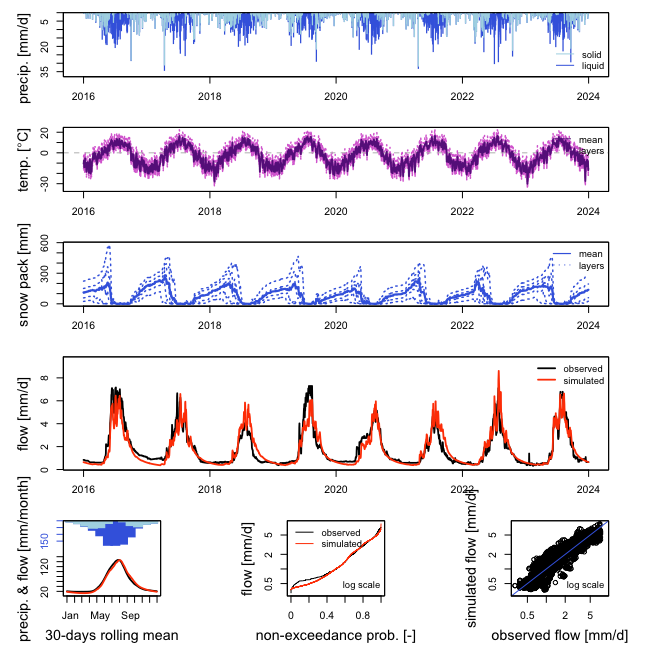

```r
load("/Volumes/Transcend/hydrosolutions Dropbox/Adrian Kreiner/SAPPHIRE_Central_Asia_Technical_Work/code/Al_Archa_model/13_Parameter/param_ModelC_it4.RData")

start_val <- "20160101"
end_val <- "20231231"
indRun_val <- seq(from = which(format(basinObsTS_SWE$date, format = "%Y%m%d") == start_val),
             to   = which(format(basinObsTS_SWE$date, format = "%Y%m%d") == end_val))

warmup <- c((indRun_val[1]-2*365):(indRun_val[1]-1))

runOptions_val <- airGR::CreateRunOptions(FUN_MOD = RunModel_CemaNeigeGR4J_Glacier,
                                    InputsModel = inputsModel,
                                    IndPeriod_Run = indRun_val,
                                    IniStates        = NULL,
                                    IniResLevels     = NULL,
                                    IndPeriod_WarmUp = warmup,
                                    MeanAnSolidPrecip = MeanAnSolidPrecip,
                                    IsHyst = FALSE,
                                    verbose = FALSE,
                                    RelIce = rel_ice)

runResults_val <- RunModel_CemaNeigeGR4J_Glacier(InputsModel   = inputsModel,
                                                      RunOptions  = runOptions_val,
                                                      Param       = param)
runResults_df <- tibble(Date = as.Date(runResults_val$DatesR), Qsim = runResults_val$Qsim)

plot(runResults_val, Qobs = basinObsTS_SWE$Qmm[indRun_val])
```

```r
inputsCrit_val <- airGR::CreateInputsCrit(FUN_CRIT    = ErrorCrit_NSE,
                                          InputsModel = inputsModel,
                                          RunOptions  = runOptions_val,
                                          Obs         = basinObsTS_SWE$Qmm[indRun_val])

ErrorCrit_val <- ErrorCrit(InputsCrit = inputsCrit_val,
                                    OutputsModel = runResults_val)
```

```
## Crit. NSE[Q] = 0.8502
```

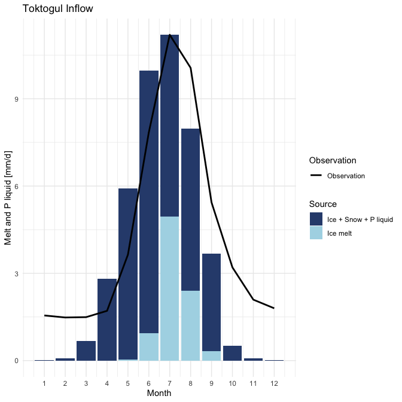

```r
NSE_val <- ErrorCrit_val$CritValue

# Visualization
WaterInput_hydrograph <- tibble(
  date = as.Date(runResults_val$DatesR),
  icemelt = runResults_val$TotGlacMelt,
  icemelt_snowmelt_liquidrain = runResults_val$CatchMeltAndPliq
) %>%
  mutate(month = month(date), year = year(date)) %>%
  group_by(month, year) %>%
  summarise(
    icemelt = mean(icemelt, na.rm = TRUE),
    icemelt_snowmelt_liquidrain = mean(icemelt_snowmelt_liquidrain, na.rm = TRUE)
  ) %>%
  ungroup() %>%
  group_by(month) %>%
  summarise(
    icemelt = mean(icemelt, na.rm = TRUE),
    icemelt_snowmelt_liquidrain = mean(icemelt_snowmelt_liquidrain, na.rm = TRUE)
  ) %>%
  ungroup()
IceMelt_percentage <- sum(WaterInput_hydrograph$icemelt) / sum(WaterInput_hydrograph$icemelt_snowmelt_liquidrain) * 100

Q_obs_monthly_2016 <-  basinObsTS_SWE%>%
  dplyr::select(date, Qmm) %>%
  mutate(month = month(date), year = year(date)) %>%
  group_by(month, year) %>%
  summarise(Qmm = mean(Qmm, na.rm = TRUE)) %>%
  ungroup() %>%
  filter(year >= 2016) %>%
  group_by(month) %>%
  summarise(Qmm = mean(Qmm, na.rm = TRUE)) %>%
  ungroup()
max_bar <- max(WaterInput_hydrograph$icemelt_snowmelt_liquidrain)
max_line <- max(Q_obs_monthly_2016$Qmm)
scale_factor <- max_line / max_bar


# Base plot
ggplot() +
  geom_bar(data = WaterInput_hydrograph, aes(x = month, y = icemelt_snowmelt_liquidrain, fill = "Ice + Snow + P liquid"), stat = "identity", position = "dodge") +
  geom_bar(data = WaterInput_hydrograph, aes(x = month, y = icemelt, fill = "Ice melt"), stat = "identity", position = "dodge") +
  geom_line(data = Q_obs_monthly_2016, aes(x = month, y = Qmm / scale_factor, color = "Observation"), size = 1) +
  scale_fill_manual(values = c("Ice + Snow + P liquid" = "#2F4B7C", "Ice melt" = "lightblue")) +
  scale_color_manual(values = c("Observation" = "black"))+
  scale_x_continuous(breaks = seq(1, 12, by = 1)) +  # Set x-axis ticks
  # scale_y_continuous(sec.axis = sec_axis(~ . * scale_factor, name = "Q [mm/d]")) +
  labs(title = "Toktogul Inflow",
       y = "Melt and P liquid [mm/d]",
       x = "Month",
       fill = "Source", color = "Observation") +
  theme_minimal()
```

## 4.3 Model benchmarking

```r
# load the data from the linear regression model
pentad_linreg <- read_csv(paste0(dir_linreg, "/forecast_pentad_linreg.csv"), show_col_types = FALSE) %>%
  filter(code == Basin_code) %>%
  dplyr::select(date, forecasted_discharge, discharge_avg, delta) %>%
  mutate(
    Qobs_pentad = discharge_avg / Basin_Info$BasinArea_m2 * 1000 * 60 * 60 * 24,  # in mm/d
    Qsim_pentad = forecasted_discharge / Basin_Info$BasinArea_m2 * 1000 * 60 * 60 * 24,  # in mm/d
    factor = delta / Basin_Info$BasinArea_m2 * 1000 * 60 * 60 * 24  # convert factor to mm/d
  ) %>%
  rename(forecast_date = date) %>%
    filter(forecast_date >= as.Date("2015-12-31")) %>%
  dplyr::select(-discharge_avg, -delta, -forecasted_discharge)

factor <- pentad_linreg %>%
  dplyr::select(forecast_date, factor, Qobs_pentad)



# calculated the Forecast accuracy from the linear regression model out of the pentadal simulations
FA_linreg<- get_accuracy_hyromet(pentad_linreg)

# Calculate otu of daily simulations pentadal simulations and check if the forecast is within the acceptable range
pentad_model <- get_pentadal_forecast_hydromet(runResults_df, factor)

# Calculate the forecast accuracy over the pentad
FA_model<- get_accuracy_hyromet(pentad_model)

FA_totmean <- mean(FA_model$percentage_flag_1)
print(paste0("The forecast accuracy of the model over all pentads is: ", FA_totmean))
```

```
## [1] "The forecast accuracy of the model over all pentads is: 0.416666666666667"
```

```r
# Only consider month from April to September (vegetation period)
FA_vegperiod <- FA_model %>%
  mutate(month = month(pentad_dates)) %>%
  filter(month >= 4 & month <= 9) %>%
  summarise(percentage_flag_1 = mean(percentage_flag_1))
print(paste0("The forecast accuracy of the model over the vegetation period is: ", FA_vegperiod$percentage_flag_1))
```

```
## [1] "The forecast accuracy of the model over the vegetation period is: 0.447916666666667"
```

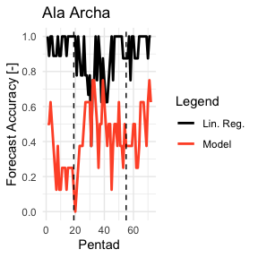

```r
# Visualization
ggplot() +
  geom_line(data = FA_linreg, aes(x = pentad, y = percentage_flag_1, color = "Lin. Reg."), linewidth = 1) +
  geom_line(data = FA_model, aes(x = pentad, y = percentage_flag_1, color = "Model"), linewidth = 1) +
  scale_color_manual(values = c("Model" = "#FF5733", "Lin. Reg." = "black")) +
  geom_vline(xintercept = 19, linetype = "dashed", color = "black") +
  geom_vline(xintercept = 55, linetype = "dashed", color = "black") +
  scale_y_continuous(limits = c(0, 1), breaks = seq(0, 1, by = 0.2)) +
  labs(
    title = "Ala Archa",
    x = 'Pentad',
    y = 'Forecast Accuracy [-]',
    color = "Legend"
  ) +
  theme_minimal()
```

# 5. Data assimilation

Discharge simulations are impacted by various sources of uncertainty, such as errors in meteorological inputs and suboptimal parameter estimates. Data assimilation (DA) combines measurements and model simulation to estimate the system state more accurately. The ensemble-based techniques allow to explicitly handle different sources of uncertainty and to quantify the unknown errors of both model states and observations. Uncertainties in meteorological forcings (e.g., precipitation and potential evapotranspiration) and model states (e.g., production store level, routing store level, and unit hydrographs) can be easily addressed by enabling specific perturbation procedures.

** Forcing perturbation ** Probabilistic forecasts are generated by stochastically perturbing model forcings (P, PET) to account for uncertainty in meteorological inputs. Random perturbations are created using a first-order autoregressive model. The fractional error parameter defines the model spread and can be adjusted (eps). Within the perturbation of the forcing input (CreateInputsPert), we can choose, similar to CreateInputsModel, whether to use the obtained basin-specific lapse rate or not (Code_lapsrate).

## 5.1 Operational Setup

## 5.2 Hindcasting

```r
# Input: startdate, enddate
start_date <- "2015-12-31"
end_date <- "2023-12-31"

# 1. get the forecasts dates
forecast_dates <- pentadal_days(start_date, end_date)

# Initialize
NbMbr <- 200
eps <- 0.65
DaMethod <- "PF"
StatePert <- c("Rout", "Prod", "UH1", "UH2")
result_list <- list()

# Inputsmodel
inputsModel <- airGR::CreateInputsModel(FUN_MOD   = RunModel_CemaNeigeGR4J_Glacier,
                                      DatesR    = basinObsTS_SWE$date,
                                      Precip    = basinObsTS_SWE$Ptot,
                                      PotEvap   = basinObsTS_SWE$PET,
                                      TempMean  = basinObsTS_SWE$Temp,
                                      HypsoData = Basin_Info$HypsoData,
                                      ZInputs   = median(Basin_Info$HypsoData),
                                      Code_lapsrate = Basin_code)

inputsPert <- CreateInputsPert(FUN_MOD = RunModel_CemaNeigeGR4J,
                               DatesR = basinObsTS_SWE$date,
                               Precip = basinObsTS_SWE$Ptot,
                               PotEvap = basinObsTS_SWE$PET,
                               TempMean  = basinObsTS_SWE$Temp,
                               HypsoData = Basin_Info$HypsoData,
                               ZInputs   = median(Basin_Info$HypsoData),
                               NbMbr = NbMbr,
                               Eps_Ptot = eps, Eps_PET = eps,
                               Code_lapsrate = Basin_code)

for (i in 1:length(forecast_dates)) {

  forecast_date <- forecast_dates[i]
  print(paste0("Forecast date: ", forecast_date))

  pentad_start <- forecast_date + 1
  pentad_end <- get_forecast_end(forecast_date)
  pentad <- get_pentad(pentad_start)


  # 2. Run periods: end_DA = pentad_end because delete discharge measurements --> no resampling
  start_DA <- forecast_date - 180
  end_OL <- start_DA - 1
  start_Ol <- as.Date("2001-01-01")

  indRun_OL <- seq(
    from = which(format(basinObsTS_SWE$date, format = "%Y-%m-%d") == format(start_Ol, format = "%Y-%m-%d")),
    to   = which(format(basinObsTS_SWE$date, format = "%Y-%m-%d") == format(end_OL, format = "%Y-%m-%d")))

  indRun_DA <- seq(
    from = which(format(basinObsTS_SWE$date, format = "%Y-%m-%d") == format(start_DA, format = "%Y-%m-%d")),
    to   = which(format(basinObsTS_SWE$date, format = "%Y-%m-%d") == format(pentad_end, format = "%Y-%m-%d")))

  # 3. Open Loop run
  warmup <- c((indRun_OL[1]-1*365):(indRun_OL[1]-1))

  runOptions_OL <- airGR::CreateRunOptions(FUN_MOD = RunModel_CemaNeigeGR4J_Glacier,
                                      InputsModel = inputsModel,
                                      IndPeriod_Run = indRun_OL,
                                      IniStates        = NULL,
                                      IniResLevels     = NULL,
                                      IndPeriod_WarmUp = warmup,
                                      MeanAnSolidPrecip = MeanAnSolidPrecip,
                                      IsHyst = FALSE,
                                      verbose = FALSE,
                                      RelIce = rel_ice)

  runResults_OL <- RunModel_CemaNeigeGR4J_Glacier(InputsModel   = inputsModel,
                                                        RunOptions  = runOptions_OL,
                                                        Param       = param)
  initstate <- runResults_OL$StateEnd

  # 4. Data assimilation run
  basinObsTS_SWE_temp <- basinObsTS_SWE %>%
    mutate(Qmm = ifelse(date > as.Date(forecast_date, format = "%Y-%m-%d") & date <= pentad_end, NA, Qmm))

  RunOptions_DA <- airGR::CreateRunOptions(FUN_MOD = RunModel_CemaNeigeGR4J_Glacier,
                                       InputsModel = inputsModel,
                                       IndPeriod_Run = 1L,
                                       warning = FALSE, verbose = FALSE,
                                       IniStates = initstate,
                                       RelIce = rel_ice)




  ResPF <- RunModel_DA(InputsModel = inputsModel,
                       InputsPert = inputsPert,
                       Qobs = basinObsTS_SWE_temp$Qmm,
                       IndRun = indRun_DA,
                       FUN_MOD = RunModel_CemaNeigeGR4J_Glacier,
                       Param = param,
                       DaMethod = DaMethod,
                       NbMbr = NbMbr,
                       StatePert = StatePert,
                       RunOptionsInitial = RunOptions_DA,
                       Rel_ice = rel_ice,
                       Seed = 40)

  ResPF_df <- process_dataset(ResPF)

  result <- data.frame(Qsim_pentad = ResPF_df %>%
                         filter(date > as.Date(forecast_date)) %>%
                         summarise(Q_mean = mean(Q_median)) %>%
                         pull(Q_mean),
                       forecast_date = forecast_date,
                       pentad_start = pentad_start,
                       pentad = pentad)

  result_list[[i]] <- result
}

final_results <- do.call(rbind, result_list)
```

Perrin, Charles, Claude Michel, and Vazken Andréassian. 2003. “Improvement of a Parsimonious Model for Streamflow Simulation.” *Journal of Hydrology* 279 (1-4): 275–89. https://doi.org/10.1016/S0022-1694(03)00225-7.

Pokhrel, Bijay Kumar, Pierre Chevallier, Vazken Andréassian, Adnan Ahmad Tahir, Yves Arnaud, Luc Neppel, Om Ratna Bajracharya, and Kamal Prakash Budhathoki. 2014. “Comparison of Two Snowmelt Modelling Approaches in the Dudh Koshi Basin (Eastern Himalayas, Nepal).” *Hydrological Sciences Journal* 59 (8): 1507–18. https://doi.org/10.1080/02626667.2013.842282.

Pushpalatha, Raji, Charles Perrin, Nicolas Le Moine, Thibault Mathevet, and Vazken Andréassian. 2011. “A Downward Structural Sensitivity Analysis of Hydrological Models to Improve Low-Flow Simulation.” *Journal of Hydrology* 411 (1–2): 66–76. https://doi.org/10.1016/j.jhydrol.2011.09.034.

Valéry, Audrey, Vazken Andréassian, and Charles Perrin. 2014. “’As Simple as Possible but Not Simpler’: What Is Useful in a Temperature-Based Snow-Accounting Routine? Part 2 - Sensitivity Analysis of the Cemaneige Snow Accounting Routine on 380 Catchments.” *Journal of Hydrology*, no. 517(0): 1176–87. https://doi.org/10.1016/j.jhydrol.2014.04.058.